# Deep Learning 101

MBAN - Winter 2024

Author

Dr. Aydede

Deep Learning is an advanced subset of machine learning that mimics the way humans gain certain types of knowledge. At its core, deep learning involves neural networks with many layers, hence the term “deep.” This depth allows models to learn complex patterns in large amounts of data, making it a powerful tool for a wide range of applications, from image and speech recognition to natural language processing.

We’ve already learned **neural networks with a single hidden layer**, which can capture a certain level of complexity in data. These networks consist of **an input layer, one hidden layer, and an output layer**. While simple neural networks are useful for learning linear relationships, their ability to model complex, nonlinear relationships is limited.

**Deep learning extends this concept by adding more hidden layers to the network**. Each layer can learn to represent the data at a different level of abstraction. The first hidden layer might learn to recognize simple shapes or patterns in the data, while subsequent layers might learn to combine these simple patterns into more complex ones. This hierarchy of learned features allows deep neural networks to tackle much more complex problems than their shallow counterparts.

**Key Concepts in Deep Learning**

- *Activation Functions*: Non-linear activation functions like ReLU (Rectified Linear Unit), Sigmoid, and Tanh help deep neural networks learn complex patterns by adding non-linearity to the model, enabling it to capture a wide variety of relationships in the data.
- *Regularization*: Techniques like dropout, L2 regularization, and batch normalization help prevent overfitting, ensuring that the model generalizes well to unseen data.
- *Optimization Algorithms*: These are methods used to minimize the loss function, guiding how the network weights are updated during training. Examples include SGD (Stochastic Gradient Descent), Adam, and RMSprop.
- *Backpropagation*: It’s basically how gradients are calculated and weights are updated in a neural network. Starting from the output layer, the method computes the gradient of the loss function with respect to each weight by chain rule, moving backward through the network’s layers. This tells us how each weight contributed to the error.

R offers several packages for deep learning, such as `keras` and `tensorflow`, which provide an interface to TensorFlow’s deep learning capabilities. These packages allow for the design, training, and deployment of deep learning models with R, making it accessible for statisticians and data scientists familiar with the language.

Simply, a Deep Neural Network (DNN), or Deep Learning, is an artificial neural network that has two or more hidden layers. Even greater flexibility is achieved via composition of activation functions:

$$y \approx \alpha+\sum_{m=1}^M \beta_m f(\alpha_m^{(1)}+\underbrace{\sum_{p=1}^P f\left(\alpha_p^{(2)}+\mathbf{X} \delta_p^{(2)}\right)}_{\text {it replaces } \mathbf{X}} \delta_m^{(1)})$$

where $f$ is the activation function, $\alpha$ and $\beta$ are the weights, and $\delta$ are the biases. The model is trained by minimizing a loss function, such as mean squared error, using optimization algorithms like stochastic gradient descent.

# 1 Single layer with `neuralnet` package

Single layer with different number of neurons:

```r
library(AER)
data("CPS1985")

df <- CPS1985

# Scaling and Dummy coding
df[,sapply(df, is.numeric)] <- scale((df[, sapply(df, is.numeric)]))
ddf <- model.matrix(~.-1, data = df, contrasts.arg =
                       lapply(df[ ,sapply(df, is.factor)],
                              contrasts, contrasts = FALSE))

ddf <- as.data.frame(ddf)

# formula to pass on ANN and lm()
w.ind <- which(colnames(ddf) == "wage")
frmnn <- as.formula(paste("wage~", paste(colnames(ddf[-w.ind]), collapse = '+')))
frmln <- as.formula(paste("wage~", "I(experience^2)", "+",
                          paste(colnames(ddf[-w.ind]), collapse = "+")))
```

```r
library(neuralnet)

mse.test <- matrix(0, 10, 5)

for (i in 1:10) {

  set.seed(i + 1)
  trainid <- sample(nrow(ddf), nrow(ddf), replace = TRUE)
  train <- ddf[trainid,]
  test <- ddf[-trainid,]

  # Models
  fit.lm <- lm(frmln, data = train)
  fit.nn <- neuralnet(frmnn, data = train, hidden = 1, threshold = 0.05)
  fit.nn2 <- neuralnet(frmnn, data = train, hidden = 2, threshold = 0.05)
  fit.nn3 <- neuralnet(frmnn, data = train, hidden = 3, threshold = 0.05)
  fit.nn4 <- neuralnet(frmnn, data = train, hidden = 3, threshold = 0.05,
                       act.fct = "tanh")

  # Prediction errors
  mse.test[i,1] <- mean((test$wage - predict(fit.lm, test))^2)
  mse.test[i,2] <- mean((test$wage - predict(fit.nn, test))^2)
  mse.test[i,3] <- mean((test$wage - predict(fit.nn2, test))^2)
  mse.test[i,4] <- mean((test$wage - predict(fit.nn3, test))^2)
  mse.test[i,5] <- mean((test$wage - predict(fit.nn4, test))^2)
}

colMeans(mse.test)
```

```
[1] 0.7491509 0.8612529 0.9555755 1.1120841 1.0340678
```

# 2 Deep Learning with `keras` package

The code below trains a deep neural network with two hidden layers, each containing 64 neurons. The model is trained on the training data and evaluated on the test data using the Mean Squared Error (MSE) and Mean Absolute Error (MAE) as metrics. The results show the test loss and test MAE for the model.

```r
library(keras)
keras::k_clear_session()

trainid <- sample(nrow(ddf), nrow(ddf), replace = TRUE)
train <- ddf[trainid, ]
test <- ddf[-trainid, ]

# Convert training predictors to a matrix
train_x <- as.matrix(train[, -which(colnames(train) == "wage")])
train_y <- train$wage
test_x <- as.matrix(test[, -which(colnames(test) == "wage")])
test_y <- test$wage

# Define model
model <- keras_model_sequential() %>%
  layer_dense(units = 64, activation = 'relu', input_shape = ncol(train) - 1) %>%
  layer_dense(units = 64, activation = 'relu') %>%
  layer_dense(units = 1)  # Output layer for regression

# Compile model
model %>% compile(
  loss = 'mean_squared_error',
  optimizer = optimizer_rmsprop(),
  metrics = list('mean_absolute_error')
)

# Fit the model
history <- model %>% fit(
  x = train_x,
  y = train_y,
  epochs = 100,
  batch_size = 128,
  validation_split = 0.2,
  verbose = 0
)

# Evaluate the model
score <- model %>% evaluate(
  x = test_x,
  y = test_y,
  verbose = 0 # No output will be shown
)

cat('Test loss:', score[1], '\n')
```

```
Test loss: 0.7745622
```

```r
cat('Test mean absolute error:', score[2], '\n')
```

```
Test mean absolute error: 0.6839558
```

**Test Loss**: This is the value of the loss function for our test dataset. In a regression problem like yours, where you might be using Mean Squared Error (MSE) as the loss function, this represents the average of the squares of the differences between the predicted and actual values across all observations in the test set. It’s a measure of how well the model is able to predict the target variable on unseen data. A lower test loss indicates better model performance.

**Test MAE (Mean Absolute Error)**: MAE is another metric used to evaluate the performance of a regression model. It’s calculated as the average of the absolute differences between the predicted and actual values across all observations in the test set. Unlike the MSE, the MAE gives a linear score, meaning all individual differences are weighted equally in the average. It’s particularly useful because it’s easy to interpret; for instance, an MAE of 5 would mean that, on average, the predicted values differ from the actual values by 5 units of the target variable.

## 2.1 Setting up a Keras Model

### 2.1.1 Step 1: Defining the Model

In Keras, a model is essentially a graph of layers. The most common type of model is a stack of layers called the Sequential model, which allows you to create models layer-by-layer in a linear fashion.

- Sequential Model: This is a linear stack of layers. You start by creating an instance of Sequential and then add layers to it. Each layer has weights that correspond to the connections between units (neurons) in this layer and the next layer.
- Layers: The building blocks of models. Layers extract representations out of the data fed into them. For most deep learning models, dense (fully connected) layers are used. The first Dense layer we add plays a special role. While technically every Dense layer is just a layer of neurons fully connected to the previous layer, the first Dense layer you add to the model also implicitly serves as the input layer. This is because it needs to know the shape of the input data it will be receiving, which you specify with the input_shape parameter.
- Activation Functions: These are applied to the output of a layer to introduce non-linearity into the model, allowing it to learn complex patterns in the data. Common activation functions include ReLU, Sigmoid, and Tanh.
- Input Shape: This specifies the shape of the input data. The input shape is the number of features in your dataset. For example, if you have 10 features, the input shape would be 10.

### 2.1.2 Step 2: Compiling the Model

After defining the model, you need to compile it. This involves specifying the loss function, optimizer, and metrics to be used during training.

- Loss Function: This is the objective that the model will try to minimize during training. For regression problems, Mean Squared Error (MSE) is commonly used.
- Optimizer: This is the algorithm used to update the weights of the model during training. Common optimizers include Stochastic Gradient Descent (SGD), Adam, and RMSprop.
- Metrics: These are used to evaluate the performance of the model. For regression problems, Mean Absolute Error (MAE) is a common metric.

### 2.1.3 Step 3: Training the Model

Once the model is compiled, you can train it on your training data. This involves passing the input data and target labels to the model and specifying the number of epochs (iterations over the entire dataset) and batch size (number of samples per gradient update).

- Epochs: One epoch is when an entire dataset is passed forward and backward through the neural network once.
- Batch Size: The number of training examples utilized in one iteration.
- Validation Split: The fraction of the training data to be used as validation data. The model will set apart this fraction of the training data, won’t train on it, and will evaluate the loss and any model metrics on this data at the end of each epoch.

### 2.1.4 Step 4: Evaluating the Model

After training the model, you can evaluate its performance on the test data. This involves passing the test data to the model and calculating the loss and metrics specified during compilation.

## 2.2 Keras with Python

Lets do the same thing with Python. First, we need to save the `ddf` dataframe to a CSV file so that we can load it in Python.

```r
write.csv(ddf, "ddf.csv", row.names = FALSE)
```

Now, we can run the following Python code to train a deep neural network on the same data and evaluate its performance on the test set.

```python
from tensorflow.keras import backend as K
from keras.models import Sequential
from keras.layers import Dense
from keras.optimizers.legacy import RMSprop
import numpy as np
import pandas as pd

# Clearing the session
K.clear_session()

# Loading the ddf dataframe from the CSV file
ddf = pd.read_csv("ddf.csv")

# Let's split the data into training and testing sets
np.random.seed(42)  # For reproducibility
sample_indices = np.random.choice(ddf.index, size = len(ddf), replace = True)
train = ddf.loc[sample_indices]
out_of_bag_indices = np.setdiff1d(ddf.index, sample_indices, assume_unique = False)
test = ddf.loc[out_of_bag_indices]

# Preparing the data
train_x = train.drop(columns=['wage']).values
train_y = train['wage'].values
test_x = test.drop(columns=['wage']).values
test_y = test['wage'].values

# Define the model
model = Sequential([
    Dense(64, activation='relu', input_shape=(train_x.shape[1],)),
    Dense(64, activation='relu'),
    Dense(1)
])

# Compile the model
model.compile(optimizer = RMSprop(), loss = 'mean_squared_error', metrics = ['mean_absolute_error'])

# Fit the model
history = model.fit(
    train_x,
    train_y,
    epochs=100,
    batch_size=128,
    validation_split=0.2,
    verbose=0
)

# Evaluate the model
score = model.evaluate(test_x, test_y, verbose=0)

print('Test loss:', score[0])
```

```
Test loss: 0.7045256495475769
```

```python
print('Test mean absolute error:', score[1])
```

```
Test mean absolute error: 0.6322771906852722
```

## 2.3 Tuning a Keras Model

Tuning a Keras model involves experimenting with various configurations of the model’s architecture, the compilation settings, and the training process to find the best performance. Here are some common ways to tune a simple Keras model:

### 2.3.1 Adjusting Layer Configurations:

- Number of Units: Vary the number of neurons in the Dense layers. More neurons can capture more complex patterns but can also lead to overfitting.
- Activation Functions: Try different activation functions (e.g., relu, tanh, sigmoid) to see how they affect model performance.

### 2.3.2 Experimenting with Optimizers:

- Different optimizers (e.g., adam, sgd, rmsprop) have different optimization algorithms and hyperparameters (like learning rate). Switching optimizers or adjusting their parameters (e.g., learning rate) can significantly impact model performance.
- Varying the Loss Functions: Depending on the problem type (regression vs. classification), different loss functions might be more appropriate. Even within a problem type, experimenting with different loss functions can yield better results.

### 2.3.3 Regularization Techniques:

To combat overfitting, try adding regularization methods such as L1 or L2 regularization, dropout layers, or batch normalization. These techniques can help the model generalize better to unseen data. L1 and L2 regularization add a penalty term to the loss function based on the weights, while dropout randomly sets a fraction of input units to zero during training to prevent overfitting. Dropout is a regularization technique that helps prevent overfitting by randomly setting a fraction of input units to zero during training. This forces the model to learn more robust features and reduces the risk of overfitting.

### 2.3.4 Model Training Adjustments:

- Epochs and Batch Size: The number of epochs and the batch size can affect how well your model learns. Too few epochs might underfit, while too many can overfit. The batch size can influence the stability and speed of the learning process. Experiment with different values to find the optimal combination.
- Validation Split: Adjusting the proportion of data used for validation can provide a better estimate of model performance on unseen data. A common choice is 20% of the training data.
- Early Stopping: Implement early stopping to halt training when the validation performance stops improving. This prevents overfitting and saves time by avoiding unnecessary epochs.

### 2.3.5 Hyperparameter Tuning Tools:

Consider using tools like Keras Tuner, Hyperopt, or scikit-learn’s GridSearchCV or RandomizedSearchCV for systematic hyperparameter tuning. These tools can help you search through a large hyperparameter space efficiently and find the best configuration for your model.

In the following example, L1 and L2 regularization, dropout, and batch normalization are added to combat overfitting. An early stopping callback halts training when the validation loss hasn’t improved for a specified number of epochs (patience), preventing overfitting and saving computational resources.

```python
from keras.layers import Dropout, BatchNormalization
from keras.regularizers import l1_l2
from keras.callbacks import EarlyStopping

model = Sequential([
    Dense(64, activation='relu', input_shape=(train_x.shape[1],), kernel_regularizer=l1_l2(l1=0.01, l2=0.01)),
    Dropout(0.5),
    BatchNormalization(),
    Dense(64, activation='relu'),
    Dense(1)
])

model.compile(optimizer='adam', loss='mean_squared_error', metrics=['mean_absolute_error'])

early_stopping = EarlyStopping(monitor='val_loss', patience=10)

history = model.fit(train_x, train_y, epochs=100, batch_size=128, validation_split=0.2, callbacks=[early_stopping], verbose=0)
```

In this example, L1 and L2 regularization are added to the first hidden layer to penalize large weights, dropout is used to prevent overfitting, and batch normalization is applied to stabilize training. The early stopping callback monitors the validation loss and stops training if it doesn’t improve for 10 epochs. These techniques can help improve the model’s generalization performance and prevent overfitting.

```python
score = model.evaluate(test_x, test_y, verbose=0)

print('Test loss:', score[0])
```

```
Test loss: 1.2156811952590942
```

```python
print('Test mean absolute error:', score[1])
```

```
Test mean absolute error: 0.6267048716545105
```

## 2.4 Visualizing Model Performance

```python
from tensorflow.keras.utils import plot_model

plot_model(model, to_file='model_plot.png', show_shapes=True, show_layer_names=True)
```

The `plot_model` function generates a visual representation of the model architecture, showing the connections between layers and the flow of data through the network. This can be useful for understanding the model’s structure and sharing it with others.

And we can plot the training history to visualize the model’s performance during training:

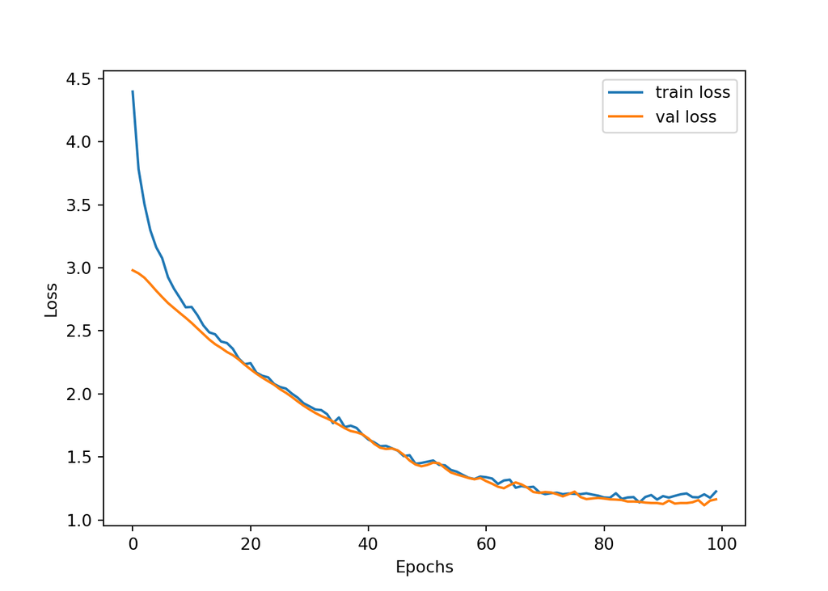

```python
import matplotlib.pyplot as plt

plt.plot(history.history['loss'], label='train loss')
plt.plot(history.history['val_loss'], label='val loss')
plt.xlabel('Epochs')
plt.ylabel('Loss')
plt.legend()
plt.show()
```